# Risk Factor Analysis

## Outcome Variable

**Outcome Variable:** dead0plus

## Predictor Variables

**Intervention Variable:** ever_underweight024

**Adjustment Set:**

- sex
- arm
- brthmon
- vagbrth
- hhwealth_quart
- W_mage
- W_mhtcm
- W_mwtkg
- W_mbmi
- W_meducyrs
- W_feducyrs
- W_nrooms
- W_parity
- impsan
- safeh20
- delta_vagbrth
- delta_hhwealth_quart
- delta_W_mage
- delta_W_mhtcm
- delta_W_mwtkg
- delta_W_mbmi
- delta_W_meducyrs
- delta_W_feducyrs
- delta_W_nrooms
- delta_W_parity
- delta_impsan
- delta_safeh20

## Stratifying Variables

The analysis was stratified on these variable(s):

- studyid
- country

## Data Summary

| studyid | country | ever_underweight024 | dead0plus | n_cell | n | outcome_variable |
| --- | --- | --- | --- | --- | --- | --- |
| ki0047075b-MAL-ED | BANGLADESH | 0 | 0 | 122 | 265 | dead0plus |
| ki0047075b-MAL-ED | BANGLADESH | 0 | 1 | 1 | 265 | dead0plus |
| ki0047075b-MAL-ED | BANGLADESH | 1 | 0 | 140 | 265 | dead0plus |
| ki0047075b-MAL-ED | BANGLADESH | 1 | 1 | 2 | 265 | dead0plus |
| ki0047075b-MAL-ED | INDIA | 0 | 0 | 97 | 251 | dead0plus |
| ki0047075b-MAL-ED | INDIA | 0 | 1 | 1 | 251 | dead0plus |
| ki0047075b-MAL-ED | INDIA | 1 | 0 | 152 | 251 | dead0plus |
| ki0047075b-MAL-ED | INDIA | 1 | 1 | 1 | 251 | dead0plus |
| ki0047075b-MAL-ED | PERU | 0 | 0 | 230 | 303 | dead0plus |
| ki0047075b-MAL-ED | PERU | 0 | 1 | 2 | 303 | dead0plus |
| ki0047075b-MAL-ED | PERU | 1 | 0 | 71 | 303 | dead0plus |
| ki0047075b-MAL-ED | PERU | 1 | 1 | 0 | 303 | dead0plus |
| ki0047075b-MAL-ED | SOUTH AFRICA | 0 | 0 | 218 | 314 | dead0plus |
| ki0047075b-MAL-ED | SOUTH AFRICA | 0 | 1 | 0 | 314 | dead0plus |
| ki0047075b-MAL-ED | SOUTH AFRICA | 1 | 0 | 95 | 314 | dead0plus |
| ki0047075b-MAL-ED | SOUTH AFRICA | 1 | 1 | 1 | 314 | dead0plus |
| ki0047075b-MAL-ED | TANZANIA, UNITED REPUBLIC OF | 0 | 0 | 146 | 262 | dead0plus |
| ki0047075b-MAL-ED | TANZANIA, UNITED REPUBLIC OF | 0 | 1 | 2 | 262 | dead0plus |
| ki0047075b-MAL-ED | TANZANIA, UNITED REPUBLIC OF | 1 | 0 | 113 | 262 | dead0plus |
| ki0047075b-MAL-ED | TANZANIA, UNITED REPUBLIC OF | 1 | 1 | 1 | 262 | dead0plus |
| ki1000109-EE | PAKISTAN | 0 | 0 | 53 | 380 | dead0plus |
| ki1000109-EE | PAKISTAN | 0 | 1 | 0 | 380 | dead0plus |
| ki1000109-EE | PAKISTAN | 1 | 0 | 323 | 380 | dead0plus |
| ki1000109-EE | PAKISTAN | 1 | 1 | 4 | 380 | dead0plus |
| ki1000304-VITAMIN-A | INDIA | 0 | 0 | 1355 | 3906 | dead0plus |
| ki1000304-VITAMIN-A | INDIA | 0 | 1 | 7 | 3906 | dead0plus |
| ki1000304-VITAMIN-A | INDIA | 1 | 0 | 2473 | 3906 | dead0plus |
| ki1000304-VITAMIN-A | INDIA | 1 | 1 | 71 | 3906 | dead0plus |
| ki1000304b-SAS-CompFeed | INDIA | 0 | 0 | 601 | 1533 | dead0plus |
| ki1000304b-SAS-CompFeed | INDIA | 0 | 1 | 15 | 1533 | dead0plus |
| ki1000304b-SAS-CompFeed | INDIA | 1 | 0 | 882 | 1533 | dead0plus |
| ki1000304b-SAS-CompFeed | INDIA | 1 | 1 | 35 | 1533 | dead0plus |
| ki1000304b-SAS-FoodSuppl | INDIA | 0 | 0 | 74 | 418 | dead0plus |
| ki1000304b-SAS-FoodSuppl | INDIA | 0 | 1 | 2 | 418 | dead0plus |
| ki1000304b-SAS-FoodSuppl | INDIA | 1 | 0 | 338 | 418 | dead0plus |
| ki1000304b-SAS-FoodSuppl | INDIA | 1 | 1 | 4 | 418 | dead0plus |
| ki1017093b-PROVIDE | BANGLADESH | 0 | 0 | 350 | 700 | dead0plus |
| ki1017093b-PROVIDE | BANGLADESH | 0 | 1 | 3 | 700 | dead0plus |
| ki1017093b-PROVIDE | BANGLADESH | 1 | 0 | 345 | 700 | dead0plus |
| ki1017093b-PROVIDE | BANGLADESH | 1 | 1 | 2 | 700 | dead0plus |
| ki1066203-TanzaniaChild2 | TANZANIA, UNITED REPUBLIC OF | 0 | 0 | 1856 | 2396 | dead0plus |
| ki1066203-TanzaniaChild2 | TANZANIA, UNITED REPUBLIC OF | 0 | 1 | 1 | 2396 | dead0plus |
| ki1066203-TanzaniaChild2 | TANZANIA, UNITED REPUBLIC OF | 1 | 0 | 539 | 2396 | dead0plus |
| ki1066203-TanzaniaChild2 | TANZANIA, UNITED REPUBLIC OF | 1 | 1 | 0 | 2396 | dead0plus |
| ki1101329-Keneba | GAMBIA | 0 | 0 | 1596 | 2929 | dead0plus |
| ki1101329-Keneba | GAMBIA | 0 | 1 | 42 | 2929 | dead0plus |
| ki1101329-Keneba | GAMBIA | 1 | 0 | 1234 | 2929 | dead0plus |
| ki1101329-Keneba | GAMBIA | 1 | 1 | 57 | 2929 | dead0plus |
| ki1112895-Burkina Faso Zn | BURKINA FASO | 0 | 0 | 4725 | 7165 | dead0plus |
| ki1112895-Burkina Faso Zn | BURKINA FASO | 0 | 1 | 22 | 7165 | dead0plus |
| ki1112895-Burkina Faso Zn | BURKINA FASO | 1 | 0 | 2392 | 7165 | dead0plus |
| ki1112895-Burkina Faso Zn | BURKINA FASO | 1 | 1 | 26 | 7165 | dead0plus |
| ki1113344-GMS-Nepal | NEPAL | 0 | 0 | 220 | 697 | dead0plus |
| ki1113344-GMS-Nepal | NEPAL | 0 | 1 | 2 | 697 | dead0plus |
| ki1113344-GMS-Nepal | NEPAL | 1 | 0 | 470 | 697 | dead0plus |
| ki1113344-GMS-Nepal | NEPAL | 1 | 1 | 5 | 697 | dead0plus |
| ki1126311-ZVITAMBO | ZIMBABWE | 0 | 0 | 10036 | 14086 | dead0plus |
| ki1126311-ZVITAMBO | ZIMBABWE | 0 | 1 | 494 | 14086 | dead0plus |
| ki1126311-ZVITAMBO | ZIMBABWE | 1 | 0 | 2932 | 14086 | dead0plus |
| ki1126311-ZVITAMBO | ZIMBABWE | 1 | 1 | 624 | 14086 | dead0plus |
| ki1148112-iLiNS-DOSE | MALAWI | 0 | 0 | 1164 | 1931 | dead0plus |
| ki1148112-iLiNS-DOSE | MALAWI | 0 | 1 | 63 | 1931 | dead0plus |
| ki1148112-iLiNS-DOSE | MALAWI | 1 | 0 | 639 | 1931 | dead0plus |
| ki1148112-iLiNS-DOSE | MALAWI | 1 | 1 | 65 | 1931 | dead0plus |
| ki1148112-iLiNS-DYAD-M | MALAWI | 0 | 0 | 773 | 1205 | dead0plus |
| ki1148112-iLiNS-DYAD-M | MALAWI | 0 | 1 | 18 | 1205 | dead0plus |
| ki1148112-iLiNS-DYAD-M | MALAWI | 1 | 0 | 388 | 1205 | dead0plus |
| ki1148112-iLiNS-DYAD-M | MALAWI | 1 | 1 | 26 | 1205 | dead0plus |
| kiGH5241-JiVitA-3 | BANGLADESH | 0 | 0 | 12880 | 27260 | dead0plus |
| kiGH5241-JiVitA-3 | BANGLADESH | 0 | 1 | 245 | 27260 | dead0plus |
| kiGH5241-JiVitA-3 | BANGLADESH | 1 | 0 | 13513 | 27260 | dead0plus |
| kiGH5241-JiVitA-3 | BANGLADESH | 1 | 1 | 622 | 27260 | dead0plus |
| kiGH5241-JiVitA-4 | BANGLADESH | 0 | 0 | 2570 | 5443 | dead0plus |
| kiGH5241-JiVitA-4 | BANGLADESH | 0 | 1 | 13 | 5443 | dead0plus |
| kiGH5241-JiVitA-4 | BANGLADESH | 1 | 0 | 2823 | 5443 | dead0plus |
| kiGH5241-JiVitA-4 | BANGLADESH | 1 | 1 | 37 | 5443 | dead0plus |

The following strata were considered:

- studyid: ki0047075b-MAL-ED, country: BANGLADESH
- studyid: ki0047075b-MAL-ED, country: INDIA
- studyid: ki0047075b-MAL-ED, country: PERU
- studyid: ki0047075b-MAL-ED, country: SOUTH AFRICA
- studyid: ki0047075b-MAL-ED, country: TANZANIA, UNITED REPUBLIC OF
- studyid: ki1000109-EE, country: PAKISTAN
- studyid: ki1000304-VITAMIN-A, country: INDIA
- studyid: ki1000304b-SAS-CompFeed, country: INDIA
- studyid: ki1000304b-SAS-FoodSuppl, country: INDIA
- studyid: ki1017093b-PROVIDE, country: BANGLADESH
- studyid: ki1066203-TanzaniaChild2, country: TANZANIA, UNITED REPUBLIC OF
- studyid: ki1101329-Keneba, country: GAMBIA
- studyid: ki1112895-Burkina Faso Zn, country: BURKINA FASO
- studyid: ki1113344-GMS-Nepal, country: NEPAL
- studyid: ki1126311-ZVITAMBO, country: ZIMBABWE
- studyid: ki1148112-iLiNS-DOSE, country: MALAWI
- studyid: ki1148112-iLiNS-DYAD-M, country: MALAWI
- studyid: kiGH5241-JiVitA-3, country: BANGLADESH
- studyid: kiGH5241-JiVitA-4, country: BANGLADESH

### Dropped Strata

Some strata were dropped due to rare outcomes:

- studyid: ki0047075b-MAL-ED, country: BANGLADESH
- studyid: ki0047075b-MAL-ED, country: INDIA
- studyid: ki0047075b-MAL-ED, country: PERU
- studyid: ki0047075b-MAL-ED, country: SOUTH AFRICA
- studyid: ki0047075b-MAL-ED, country: TANZANIA, UNITED REPUBLIC OF
- studyid: ki1000109-EE, country: PAKISTAN
- studyid: ki1000304b-SAS-FoodSuppl, country: INDIA
- studyid: ki1017093b-PROVIDE, country: BANGLADESH
- studyid: ki1066203-TanzaniaChild2, country: TANZANIA, UNITED REPUBLIC OF
- studyid: ki1113344-GMS-Nepal, country: NEPAL

## Methods Detail

We’re interested in the causal parameters $E[Y_a]$ for all values of $a \in \mathcal{A}$. These parameters represent the mean outcome if, possibly contrary to fact, we intervened to set all units to have $A=a$. Under the randomization and positivity assumptions, these are identified by the statistical parameters $\psi_a=E_W[E_{Y|A,W}(Y|A=a,W)]$. In addition, we’re interested in the mean of $Y$, $E[Y]$ under no intervention (the observed mean). We will estimate these parameters by using SuperLearner to fit the relevant likelihood factors – $E_{Y|A,W}(Y|A=a,W)$ and $p(A=a|W)$, and then updating our likelihood fit using a joint TMLE.

For unadjusted analyses ($W=\{\}$), initial likelihoods were estimated using Lrnr_glm to estimate the simple $E(Y|A)$ and Lrnr_mean to estimate $p(A)$. For adjusted analyses, a small library containing Lrnr_glmnet, Lrnr_xgboost, and Lrnr_mean was used.

Having estimated these parameters, we will then use the delta method to estimate relative risks and attributable risks relative to a prespecified baseline level of $A$.

# Results Detail

## Results Plots

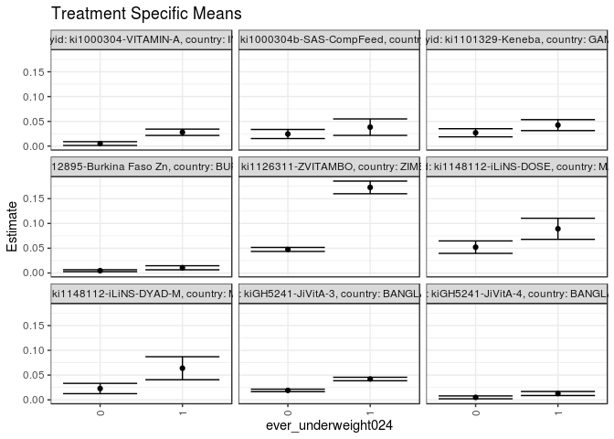

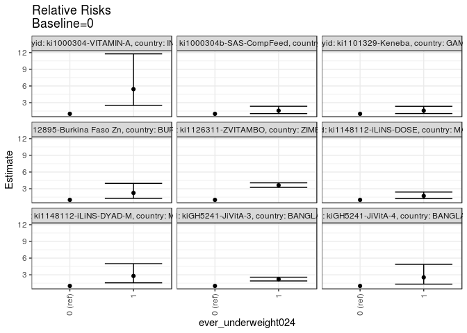

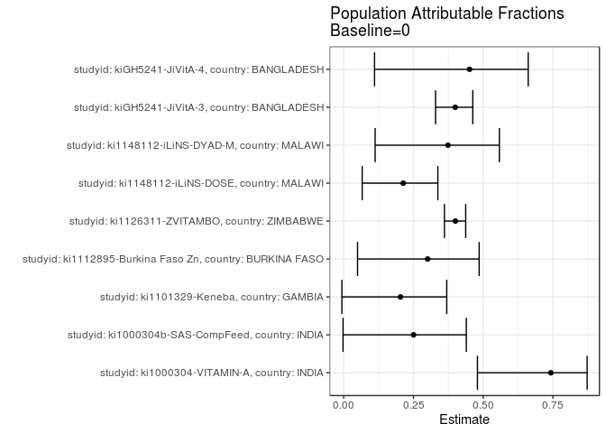

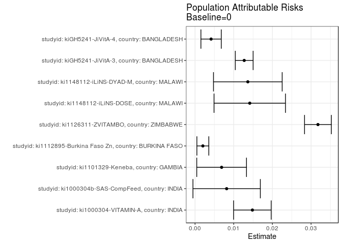

## Results Table

### Parameter: TSM

| studyid | country | intervention_level | baseline_level | estimate | ci_lower | ci_upper |
| --- | --- | --- | --- | --- | --- | --- |
| ki1000304-VITAMIN-A | INDIA | 0 | NA | 0.0051395 | 0.0013415 | 0.0089375 |
| ki1000304-VITAMIN-A | INDIA | 1 | NA | 0.0279088 | 0.0215075 | 0.0343101 |
| ki1000304b-SAS-CompFeed | INDIA | 0 | NA | 0.0244482 | 0.0152421 | 0.0336543 |
| ki1000304b-SAS-CompFeed | INDIA | 1 | NA | 0.0382645 | 0.0216596 | 0.0548695 |
| ki1101329-Keneba | GAMBIA | 0 | NA | 0.0269319 | 0.0187416 | 0.0351223 |
| ki1101329-Keneba | GAMBIA | 1 | NA | 0.0423958 | 0.0313388 | 0.0534528 |
| ki1112895-Burkina Faso Zn | BURKINA FASO | 0 | NA | 0.0046846 | 0.0027296 | 0.0066395 |
| ki1112895-Burkina Faso Zn | BURKINA FASO | 1 | NA | 0.0105156 | 0.0064356 | 0.0145955 |
| ki1126311-ZVITAMBO | ZIMBABWE | 0 | NA | 0.0475912 | 0.0434985 | 0.0516839 |
| ki1126311-ZVITAMBO | ZIMBABWE | 1 | NA | 0.1727164 | 0.1599518 | 0.1854811 |
| ki1148112-iLiNS-DOSE | MALAWI | 0 | NA | 0.0521424 | 0.0396034 | 0.0646813 |
| ki1148112-iLiNS-DOSE | MALAWI | 1 | NA | 0.0892177 | 0.0679102 | 0.1105251 |
| ki1148112-iLiNS-DYAD-M | MALAWI | 0 | NA | 0.0228688 | 0.0124737 | 0.0332638 |
| ki1148112-iLiNS-DYAD-M | MALAWI | 1 | NA | 0.0638454 | 0.0406115 | 0.0870792 |
| kiGH5241-JiVitA-3 | BANGLADESH | 0 | NA | 0.0190931 | 0.0166126 | 0.0215737 |
| kiGH5241-JiVitA-3 | BANGLADESH | 1 | NA | 0.0420877 | 0.0385507 | 0.0456246 |
| kiGH5241-JiVitA-4 | BANGLADESH | 0 | NA | 0.0050417 | 0.0021458 | 0.0079376 |
| kiGH5241-JiVitA-4 | BANGLADESH | 1 | NA | 0.0128052 | 0.0087283 | 0.0168821 |

### Parameter: E(Y)

| studyid | country | intervention_level | baseline_level | estimate | ci_lower | ci_upper |
| --- | --- | --- | --- | --- | --- | --- |
| ki1000304-VITAMIN-A | INDIA | NA | NA | 0.0199693 | 0.0155816 | 0.0243570 |
| ki1000304b-SAS-CompFeed | INDIA | NA | NA | 0.0326158 | 0.0204960 | 0.0447355 |
| ki1101329-Keneba | GAMBIA | NA | NA | 0.0337999 | 0.0272543 | 0.0403456 |
| ki1112895-Burkina Faso Zn | BURKINA FASO | NA | NA | 0.0066992 | 0.0048103 | 0.0085882 |
| ki1126311-ZVITAMBO | ZIMBABWE | NA | NA | 0.0793696 | 0.0749054 | 0.0838337 |
| ki1148112-iLiNS-DOSE | MALAWI | NA | NA | 0.0662869 | 0.0551877 | 0.0773861 |
| ki1148112-iLiNS-DYAD-M | MALAWI | NA | NA | 0.0365145 | 0.0259198 | 0.0471093 |
| kiGH5241-JiVitA-3 | BANGLADESH | NA | NA | 0.0318048 | 0.0296069 | 0.0340028 |
| kiGH5241-JiVitA-4 | BANGLADESH | NA | NA | 0.0091861 | 0.0065991 | 0.0117731 |

### Parameter: RR

| studyid | country | intervention_level | baseline_level | estimate | ci_lower | ci_upper |
| --- | --- | --- | --- | --- | --- | --- |
| ki1000304-VITAMIN-A | INDIA | 0 | 0 | 1.000000 | 1.000000 | 1.000000 |
| ki1000304-VITAMIN-A | INDIA | 1 | 0 | 5.430256 | 2.504838 | 11.772289 |
| ki1000304b-SAS-CompFeed | INDIA | 0 | 0 | 1.000000 | 1.000000 | 1.000000 |
| ki1000304b-SAS-CompFeed | INDIA | 1 | 0 | 1.565125 | 1.040312 | 2.354696 |
| ki1101329-Keneba | GAMBIA | 0 | 0 | 1.000000 | 1.000000 | 1.000000 |
| ki1101329-Keneba | GAMBIA | 1 | 0 | 1.574183 | 1.054378 | 2.350250 |
| ki1112895-Burkina Faso Zn | BURKINA FASO | 0 | 0 | 1.000000 | 1.000000 | 1.000000 |
| ki1112895-Burkina Faso Zn | BURKINA FASO | 1 | 0 | 2.244720 | 1.269767 | 3.968263 |
| ki1126311-ZVITAMBO | ZIMBABWE | 0 | 0 | 1.000000 | 1.000000 | 1.000000 |
| ki1126311-ZVITAMBO | ZIMBABWE | 1 | 0 | 3.629169 | 3.242054 | 4.062507 |
| ki1148112-iLiNS-DOSE | MALAWI | 0 | 0 | 1.000000 | 1.000000 | 1.000000 |
| ki1148112-iLiNS-DOSE | MALAWI | 1 | 0 | 1.711040 | 1.218706 | 2.402266 |
| ki1148112-iLiNS-DYAD-M | MALAWI | 0 | 0 | 1.000000 | 1.000000 | 1.000000 |
| ki1148112-iLiNS-DYAD-M | MALAWI | 1 | 0 | 2.791815 | 1.558109 | 5.002367 |
| kiGH5241-JiVitA-3 | BANGLADESH | 0 | 0 | 1.000000 | 1.000000 | 1.000000 |
| kiGH5241-JiVitA-3 | BANGLADESH | 1 | 0 | 2.204337 | 1.893772 | 2.565833 |
| kiGH5241-JiVitA-4 | BANGLADESH | 0 | 0 | 1.000000 | 1.000000 | 1.000000 |
| kiGH5241-JiVitA-4 | BANGLADESH | 1 | 0 | 2.539867 | 1.322976 | 4.876068 |

### Parameter: PAR

| studyid | country | intervention_level | baseline_level | estimate | ci_lower | ci_upper |
| --- | --- | --- | --- | --- | --- | --- |
| ki1000304-VITAMIN-A | INDIA | 0 | NA | 0.0148298 | 0.0099700 | 0.0196895 |
| ki1000304b-SAS-CompFeed | INDIA | 0 | NA | 0.0081676 | -0.0005441 | 0.0168793 |
| ki1101329-Keneba | GAMBIA | 0 | NA | 0.0068680 | 0.0004375 | 0.0132985 |
| ki1112895-Burkina Faso Zn | BURKINA FASO | 0 | NA | 0.0020146 | 0.0004697 | 0.0035596 |
| ki1126311-ZVITAMBO | ZIMBABWE | 0 | NA | 0.0317784 | 0.0283103 | 0.0352465 |
| ki1148112-iLiNS-DOSE | MALAWI | 0 | NA | 0.0141445 | 0.0049053 | 0.0233838 |
| ki1148112-iLiNS-DYAD-M | MALAWI | 0 | NA | 0.0136458 | 0.0047636 | 0.0225280 |
| kiGH5241-JiVitA-3 | BANGLADESH | 0 | NA | 0.0127117 | 0.0104067 | 0.0150168 |
| kiGH5241-JiVitA-4 | BANGLADESH | 0 | NA | 0.0041444 | 0.0015120 | 0.0067768 |

### Parameter: PAF

| studyid | country | intervention_level | baseline_level | estimate | ci_lower | ci_upper |
| --- | --- | --- | --- | --- | --- | --- |
| ki1000304-VITAMIN-A | INDIA | 0 | NA | 0.7426296 | 0.4793676 | 0.8727711 |
| ki1000304b-SAS-CompFeed | INDIA | 0 | NA | 0.2504179 | -0.0025483 | 0.4395548 |
| ki1101329-Keneba | GAMBIA | 0 | NA | 0.2031956 | -0.0066581 | 0.3693020 |
| ki1112895-Burkina Faso Zn | BURKINA FASO | 0 | NA | 0.3007281 | 0.0494692 | 0.4855704 |
| ki1126311-ZVITAMBO | ZIMBABWE | 0 | NA | 0.4003851 | 0.3610712 | 0.4372800 |
| ki1148112-iLiNS-DOSE | MALAWI | 0 | NA | 0.2133834 | 0.0661668 | 0.3373917 |
| ki1148112-iLiNS-DYAD-M | MALAWI | 0 | NA | 0.3737077 | 0.1125739 | 0.5580003 |
| kiGH5241-JiVitA-3 | BANGLADESH | 0 | NA | 0.3996789 | 0.3292185 | 0.4627380 |
| kiGH5241-JiVitA-4 | BANGLADESH | 0 | NA | 0.4511618 | 0.1103816 | 0.6614016 |